# IE582_Fall21_Homework5

```r
require(data.table)
require(skimr)
require(ROSE)
require(caret)
require(ranger)
require(gbm)
require(DMwR)
#Sys.setlocale(locale='Chinese')
```

```r
current_folder = getwd()

train = fread('train.csv')
test = fread('test.csv')
```

```r
head(train)
```

| loan_application_id | loan_amount | default | customer_age | Var_1 | Var_2 | Var_3 | Var_4 | Var_5 | Var_6 | ... | Var_50 | Var_51 | Var_52 | Var_53 | Var_54 | Var_55 | Var_56 | Var_57 | Var_58 | Var_59 |
| --- | --- | --- | --- | --- | --- | --- | --- | --- | --- | --- | --- | --- | --- | --- | --- | --- | --- | --- | --- | --- |
| 1 | 2855.0 | 0 | 25 | 3 | 1 | 1 | 37 | 41 | 5 | ... | 0 | 0 | 0 | N | 0.0 | 0 | 0 | 1 | 1 | 0 |
| 2 | 1577.0 | 0 | 53 | 0 | 0 | 0 | 0 | 26 | 2 | ... | 0 | 0 | 0 | N | 0.0 | 0 | 0 | 0 | 1 | 0 |
| 3 | 6858.0 | 0 | 39 | 4 | 2 | 3 | 55 | 58 | 10 | ... | 700 | 0 | 700 | N | 700.0 | 0 | 0 | 4 | 6 | 0 |
| 4 | 2434.5 | 0 | 49 | 3 | 1 | 3 | 98 | 98 | 11 | ... | 16350 | 127 | 16935 | N | 8467.5 | 0 | 0 | 0 | 5 | 0 |
| 5 | 4964.0 | 0 | 47 | 2 | 1 | 1 | 110 | 124 | 15 | ... | 3000 | 142 | 3400 | N | 1700.0 | 0 | 0 | 2 | 10 | 0 |
| 7 | 6899.0 | 0 | 44 | 1 | 0 | 1 | 37 | 37 | 5 | ... | 150 | 0 | 150 | N | 150.0 | 0 | 0 | 0 | 3 | 0 |

```r
head(test)
```

| loan_application_id | loan_amount | default | customer_age | Var_1 | Var_2 | Var_3 | Var_4 | Var_5 | Var_6 | ... | Var_50 | Var_51 | Var_52 | Var_53 | Var_54 | Var_55 | Var_56 | Var_57 | Var_58 | Var_59 |
| --- | --- | --- | --- | --- | --- | --- | --- | --- | --- | --- | --- | --- | --- | --- | --- | --- | --- | --- | --- | --- |
| 6 | 2106.0 | NA | 58 | 2 | 0 | 6 | 101 | 101 | 20 | ... | 1500 | 1533 | 3300 | N | 1100 | 0 | 0 | 1 | 5 | 0 |
| 9 | 4034.0 | NA | 49 | 2 | 2 | 3 | 53 | 76 | 15 | ... | 500 | 141 | 650 | N | 325 | 0 | 0 | 4 | 7 | 0 |
| 18 | 2742.0 | NA | 64 | 2 | 0 | 1 | 54 | 54 | 5 | ... | 500 | 0 | 500 | N | 500 | 8729 | 294 | 0 | 5 | 0 |
| 20 | 1752.0 | NA | 69 | 4 | 1 | 2 | 140 | 140 | 12 | ... | 2250 | 0 | 2250 | N | 2250 | 6075 | 607 | 0 | 8 | 0 |
| 22 | 2340.5 | NA | 31 | 1 | 1 | 1 | 28 | 87 | 4 | ... | 0 | 0 | 0 | N | 0 | 0 | 0 | 0 | 2 | 0 |
| 23 | 2138.0 | NA | 28 | 4 | 0 | 0 | 112 | 112 | 8 | ... | 1000 | 173 | 1000 | N | 1000 | 0 | 0 | 1 | 3 | 0 |

### Step1: Descriptive Analysis

```r
skim(train)
```

```
-- Data Summary ------------------------
                           Values
Name                       train
Number of rows             1715
Number of columns          63
Key                        NULL
_______________________
Column type frequency:
  character                2
  numeric                  61
________________________
Group variables            None
```

```
-- Variable type: character ----------------------------------------------------
# A tibble: 2 x 8
  skim_variable n_missing complete_rate   min   max empty n_unique whitespace
* <chr>             <int>         <dbl> <int> <int> <int>    <int>      <int>
1 Var_39                0             1     1     1     0        2          0
2 Var_53                0             1     1     1     0        2          0
```

```
-- Variable type: numeric ------------------------------------------------------
# A tibble: 61 x 11
   skim_variable       n_missing complete_rate      mean        sd    p0     p25
 * <chr>                   <int>         <dbl>     <dbl>     <dbl> <dbl>   <dbl>
 1 loan_application_id         0             1  1273.      749.        1  618.
 2 loan_amount                 0             1  2949.     1323.      771 1969.
 3 default                     0             1     0.100     0.300     0    0
 4 customer_age                0             1    41.3      13.7      19   29
 5 Var_1                       0             1     2.43      1.52      0    1
 6 Var_2                       0             1     1.17      1.96      0    0
 7 Var_3                       0             1     2.83      4.36      0    0
 8 Var_4                       0             1    76.8      56.4       0   32
 9 Var_5                       0             1    91.4      59.9       0   46
10 Var_6                       0             1     9.01      6.23      1    5
11 Var_7                       0             1     9.15      6.30      1    5
```

[output cut: 113 more lines]

```r
skim(test)
```

```
-- Data Summary ------------------------
                           Values
Name                       test
Number of rows             847
Number of columns          63
Key                        NULL
_______________________
Column type frequency:
  character                2
  logical                  1
  numeric                  60
________________________
Group variables            None
```

```
-- Variable type: character ----------------------------------------------------
# A tibble: 2 x 8
  skim_variable n_missing complete_rate   min   max empty n_unique whitespace
* <chr>             <int>         <dbl> <int> <int> <int>    <int>      <int>
1 Var_39                0             1     1     1     0        2          0
2 Var_53                0             1     1     1     0        2          0
```

```
-- Variable type: logical ------------------------------------------------------
# A tibble: 1 x 5
  skim_variable n_missing complete_rate  mean count
* <chr>             <int>         <dbl> <dbl> <chr>
1 default             847             0   NaN ": "
```

```
-- Variable type: numeric ------------------------------------------------------
# A tibble: 60 x 11
   skim_variable       n_missing complete_rate      mean        sd    p0    p25
 * <chr>                   <int>         <dbl>     <dbl>     <dbl> <dbl>  <dbl>
 1 loan_application_id         0             1  1298.      721.        6  678.
 2 loan_amount                 0             1  2999.     1403.      783 1931
 3 customer_age                0             1    42.0      14.3      19   29
 4 Var_1                       0             1     2.45      1.61      0    1
 5 Var_2                       0             1     1.22      2.11      0    0
 6 Var_3                       0             1     2.73      4.27      0    0
 7 Var_4                       0             1    77.9      59.0       0   33
 8 Var_5                       0             1    93.2      63.3       5   45
 9 Var_6                       0             1     8.87      6.10      1    5
10 Var_7                       0             1     9.03      6.15      1    5
11 Var_8                       0             1  1263.      269.        0 1092
```

[output cut: 111 more lines]

### Step2: Preprocessing

```r
#check table
table(train$default)
```

```
   0    1
1543  172
```

```r
#check classes distribution
prop.table(table(train$default))
```

```
        0         1
0.8997085 0.1002915
```

```r
# there are some columns to be converted to categoric
train[, c("Var_39", "Var_53")] = lapply(train[, c("Var_39", "Var_53")] , factor)
train[,type:=as.factor(ifelse(default==1, "Bad", "Good"))]
```

###### Also different from the final, instead of using age in numeric type I will try it in categoric type. This requires a little bit preprocess.

```r
min(train$customer_age)
```

19

```r
max(train$customer_age)
```

74

```r
train[,age_cluster:=cut(customer_age, breaks=c(18,25,30,45,74), labels=c("young", "graduate", "middle-age", "old"))]
```

###### Looks like we have an imbalanced problem. So it is needed to be change to balanced problem before model building. There are several methods to that. Besides the final execution, this time I won't be using the Over Sampling method. This time I will change the problem to balanced one with SMOTE method.

```r
#train_balanced = as.data.table(ovun.sample(default ~ ., data = train, method = "over", N = 3085)$data)
```

```r
train_smote_balanced = SMOTE(type~., train[,-c("loan_application_id","default")])
```

```r
table(train_smote_balanced$type)
```

```
 Bad Good
 516  688
```

```r
#plot(type~customer_age, train_balanced)
```

```r
#plot(type~customer_age, train)
```

### Step3: Model Building

```r
# first we need to write our performance measure

performance = function(data, lev, model){
    obs = data$obs # actual default value
    preds = data$pred # predictions
    # this part is added different from the final, because it filters the loans based on instance index which are used in each fold
    index = data$rowIndex
    loan = data$weights[index]
    two_class = twoClassSummary(data, lev, model)
    for (i in 1:length(obs)){
        if(obs[i]=="Bad"&preds[i]=="Good"){
           x = loan[i]*(-1)
        } else if (obs[i]=="Good"&preds[i]=="Bad"){
           x = loan[i]*0.15*(-1)
        } else if (obs[i]=="Good"&preds[i]=="Good"){
           x = 0
        } else if (obs[i]=="Bad"&preds[i]=="Bad"){
           x = 0
        }
      cost[[i]] = x
    }
    customer_cost = do.call(rbind, cost)
    total_cost = colSums(customer_cost, na.rm = T)
    names(total_cost) = "Cost"
    combined = c(two_class, total_cost)
    combined
}
```

```r
cost = list()
n_repeats=5
n_folds=10
```

```r
head(train_smote_balanced)
```

| loan_amount | customer_age | Var_1 | Var_2 | Var_3 | Var_4 | Var_5 | Var_6 | Var_7 | Var_8 | ... | Var_52 | Var_53 | Var_54 | Var_55 | Var_56 | Var_57 | Var_58 | Var_59 | type | age_cluster |
| --- | --- | --- | --- | --- | --- | --- | --- | --- | --- | --- | --- | --- | --- | --- | --- | --- | --- | --- | --- | --- |
| 1998.0 | 42 | 3 | 5 | 12 | 26 | 26 | 10 | 10 | 986 | ... | 2776 | N | 1388 | 19489 | 589 | 3 | 7 | 0 | Good | middle-age |
| 1325.0 | 40 | 1 | 0 | 0 | 96 | 96 | 5 | 5 | 1578 | ... | 500 | N | 500 | 0 | 0 | 0 | 3 | 0 | Good | middle-age |
| 1397.5 | 64 | 3 | 0 | 0 | 115 | 115 | 4 | 4 | 1747 | ... | 0 | N | 0 | 0 | 0 | 0 | 1 | 0 | Good | old |
| 2946.0 | 49 | 2 | 0 | 0 | 88 | 165 | 7 | 7 | 1507 | ... | 250 | N | 250 | 0 | 0 | 2 | 4 | 0 | Good | old |
| 2453.0 | 29 | 3 | 0 | 2 | 61 | 61 | 7 | 7 | 1032 | ... | 700 | N | 700 | 0 | 0 | 2 | 7 | 0 | Good | graduate |
| 6754.0 | 24 | 2 | 0 | 3 | 32 | 32 | 10 | 10 | 1221 | ... | 2000 | N | 2000 | 0 | 0 | 1 | 8 | 0 | Good | young |

#### CART

```r
set.seed(1)

fitControl = trainControl(method = "repeatedcv",
                          number = n_folds,
                          repeats = n_repeats,
                          classProbs=TRUE,
                          summaryFunction=performance)

tree_fit = train(type ~ ., data = train_smote_balanced[,-c("customer_age", "loan_amount")],
                 method = "rpart",
                 trControl = fitControl,
                 metric = "Cost",
                 weights = loans_train,
                 tuneLength = 5)
```

```r
tree_fit
```

```
CART

1204 samples
  60 predictor
   2 classes: 'Bad', 'Good'

No pre-processing
Resampling: Cross-Validated (10 fold, repeated 5 times)
Summary of sample sizes: 1084, 1083, 1084, 1083, 1083, 1085, ...
Resampling results across tuning parameters:

  cp          ROC        Sens       Spec       Cost
  0.01356589  0.8001654  0.7739065  0.7863683   -885.6763
  0.01453488  0.8000121  0.7715535  0.7869523   -885.6763
  0.02519380  0.7727767  0.7797662  0.7401705  -1165.4127
  0.07945736  0.7567829  0.7526998  0.7120418  -1238.0125
  0.39922481  0.5617983  0.2333409  0.8902558   -422.4432

Cost was used to select the optimal model using the largest value.
The final value used for the model was cp = 0.3992248.
```

#### Lasso Regression

```r
set.seed(1)

fitControl = trainControl(method = "repeatedcv",
                          number = n_folds,
                          repeats = n_repeats,
                          classProbs=TRUE,
                          summaryFunction=performance)

glm_fit = train(type ~ .,
                data = train_smote_balanced[,-c("customer_age", "loan_amount")],
                method = "glmnet",
                trControl = fitControl,
                metric = "Cost",
                weights = loans_train,
                tuneLength = 5)
```

```r
glm_fit
```

```
glmnet

1204 samples
  60 predictor
   2 classes: 'Bad', 'Good'

No pre-processing
Resampling: Cross-Validated (10 fold, repeated 5 times)
Summary of sample sizes: 1084, 1083, 1084, 1083, 1083, 1085, ...
Resampling results across tuning parameters:

  alpha  lambda        ROC        Sens       Spec       Cost
  0.100  0.0001816435  0.8510572  0.7639970  0.8049446  -1017.7955
  0.100  0.0008431143  0.8533032  0.7605053  0.8093137  -1069.4066
  0.100  0.0039133900  0.8551423  0.7581222  0.8125149  -1092.3558
  0.100  0.0181643481  0.8557052  0.7465158  0.8217988   -957.1243
  0.100  0.0843114393  0.8474660  0.7058145  0.8314109   -816.3003
  0.325  0.0001816435  0.8509779  0.7616667  0.8049403  -1022.6990
  0.325  0.0008431143  0.8536855  0.7597210  0.8087340  -1057.1576
  0.325  0.0039133900  0.8553575  0.7561614  0.8139685  -1080.4515
  0.325  0.0181643481  0.8522256  0.7282504  0.8238491   -915.1802
  0.325  0.0843114393  0.8372856  0.6674133  0.8276300   -850.4043
  0.550  0.0001816435  0.8511206  0.7628356  0.8049403  -1022.6990
  0.550  0.0008431143  0.8539784  0.7589442  0.8093137  -1062.0611
  0.550  0.0039133900  0.8550742  0.7550302  0.8174595  -1039.1139
  0.550  0.0181643481  0.8481362  0.6995852  0.8276257   -865.7162
  0.550  0.0843114393  0.8344582  0.6297813  0.8389685   -815.8495
  0.775  0.0001816435  0.8511662  0.7612821  0.8049446  -1033.6070
  0.775  0.0008431143  0.8540608  0.7593363  0.8096078  -1050.1568
  0.775  0.0039133900  0.8550304  0.7554223  0.8197783  -1015.0626
  0.775  0.0181643481  0.8463568  0.6887481  0.8325661   -806.1452
  0.775  0.0843114393  0.8315797  0.5894268  0.8543905   -720.6020
  1.000  0.0001816435  0.8509482  0.7616742  0.8055243  -1033.6070
  1.000  0.0008431143  0.8540636  0.7593363  0.8110699  -1088.4404
  1.000  0.0039133900  0.8549517  0.7550452  0.8197783   -986.8056
  1.000  0.0181643481  0.8443951  0.6818024  0.8290921   -826.2782
  1.000  0.0843114393  0.8218612  0.5449020  0.8614024   -720.4546

Cost was used to select the optimal model using the largest value.
The final values used for the model were alpha = 1 and lambda = 0.08431144.
```

#### Random Forest

```r
set.seed(1)

fitControl = trainControl(method = "repeatedcv",
                        number = n_folds,
                        repeats = n_repeats,
                        classProbs=TRUE,
                        summaryFunction=performance)

rf_grid = expand.grid(mtry = c(2, 10, 25, 50),
                      splitrule = c("gini", "extratrees"),
                      min.node.size = 5)

rf_fit = train(type ~ .,
               data = train_smote_balanced[,-c("customer_age", "loan_amount")],
               method = "ranger",
               trControl = fitControl,
               metric = "Cost",
               weights = loans_train,
               tuneGrid = rf_grid)
```

```r
rf_fit
```

```
Random Forest

1204 samples
  60 predictor
   2 classes: 'Bad', 'Good'

No pre-processing
Resampling: Cross-Validated (10 fold, repeated 5 times)
Summary of sample sizes: 1084, 1083, 1084, 1083, 1083, 1085, ...
Resampling results across tuning parameters:

  mtry  splitrule   ROC        Sens       Spec       Cost
   2    gini        0.9618113  0.8333861  0.9223956  -308.1601
   2    extratrees  0.9546791  0.8465460  0.9160102  -457.2292
  10    gini        0.9566592  0.8589517  0.9017604  -361.8781
  10    extratrees  0.9506586  0.8538989  0.9032225  -541.8716
  25    gini        0.9509050  0.8558069  0.8915985  -380.7847
  25    extratrees  0.9465911  0.8531146  0.8965558  -568.4405
  50    gini        0.9469405  0.8596682  0.8840537  -429.2157
  50    extratrees  0.9453164  0.8612519  0.8889898  -596.3770

Tuning parameter 'min.node.size' was held constant at a value of 5
Cost was used to select the optimal model using the largest value.
The final values used for the model were mtry = 2, splitrule = gini
 and min.node.size = 5.
```

#### GBM

```r
set.seed(1)

fitControl=trainControl(method = "repeatedcv",
                        number = n_folds,
                        repeats = n_repeats,
                        classProbs=TRUE,
                        summaryFunction=performance)

gbmGrid = expand.grid(interaction.depth = c(3, 4, 5),
                      n.trees = c(3:5)*50,
                      shrinkage = c(0.01, 0.05, 0.1),
                      n.minobsinnode = 5)

gbm_fit = train(type ~ .,
                data = train_smote_balanced[,-c("customer_age", "loan_amount")],
                method = "gbm",
                trControl = fitControl,
                metric = "Cost",
                weights = loans_train,
                tuneGrid = gbmGrid)
```

```r
gbm_fit
```

```
Stochastic Gradient Boosting

1204 samples
  60 predictor
   2 classes: 'Bad', 'Good'

No pre-processing
Resampling: Cross-Validated (10 fold, repeated 5 times)
Summary of sample sizes: 1084, 1083, 1084, 1083, 1083, 1085, ...
Resampling results across tuning parameters:

  shrinkage  interaction.depth  n.trees  ROC        Sens       Spec
  0.01       3                  150      0.8762406  0.7964630  0.7988960
  0.01       3                  200      0.8831623  0.8050226  0.8015132
  0.01       3                  250      0.8893930  0.8077149  0.8073061
  0.01       4                  150      0.8851555  0.7984012  0.8102174
  0.01       4                  200      0.8920731  0.8026772  0.8139940
  0.01       4                  250      0.8984217  0.8065535  0.8212702
  0.01       5                  150      0.8921089  0.7984238  0.8160273
  0.01       5                  200      0.8988007  0.8057919  0.8221355
  0.01       5                  250      0.9058698  0.8077300  0.8326130
  0.05       3                  150      0.9186654  0.8151433  0.8561253
  0.05       3                  200      0.9246789  0.8263725  0.8691816
  0.05       3                  250      0.9280808  0.8332956  0.8770418
  0.05       4                  150      0.9246802  0.8267647  0.8759079
  0.05       4                  200      0.9298855  0.8356863  0.8837511
  0.05       4                  250      0.9339818  0.8372323  0.8886786
  0.05       5                  150      0.9297483  0.8329638  0.8790793
  0.05       5                  200      0.9338059  0.8430392  0.8849020
  0.05       5                  250      0.9367792  0.8469457  0.8895396
  0.10       3                  150      0.9276676  0.8279487  0.8805584
  0.10       3                  200      0.9319918  0.8330015  0.8825789
  0.10       3                  250      0.9349456  0.8360332  0.8875149
  0.10       4                  150      0.9334003  0.8418477  0.8881032
  0.10       4                  200      0.9369050  0.8461011  0.8915729
  0.10       4                  250      0.9395287  0.8558296  0.8927153
  0.10       5                  150      0.9375544  0.8480769  0.8886616
  0.10       5                  200      0.9392029  0.8511161  0.8944842
  0.10       5                  250      0.9426672  0.8561991  0.8956522
  Cost
```

[output cut: 17 more lines]

```
  -419.8209
  -469.4962
  -496.4994
  -520.2459
  -410.9251
  -435.4823
  -471.6447
  -500.1703
  -473.6777
  -464.1384

Tuning parameter 'n.minobsinnode' was held constant at a value of 5
Cost was used to select the optimal model using the largest value.
The final values used for the model were n.trees = 150, interaction.depth =
 4, shrinkage = 0.05 and n.minobsinnode = 5.
```

#### SVM

```r
set.seed(1)
fitControl = trainControl(method = "repeatedcv",
                         number = n_folds,
                         repeats = n_repeats,
                         classProbs=TRUE,
                         summaryFunction=performance,
                         preProc = c("center", "scale", "nzv"))

svm_fit = train(type ~ .,
                data = train_smote_balanced[,-c("customer_age", "loan_amount")],
                method = "svmRadialWeights",
                trControl = fitControl,
                metric = "Cost",
                weights = loans_train,
                tuneLength = 4)
```

```r
svm_fit
```

```
Support Vector Machines with Class Weights

1204 samples
  60 predictor
   2 classes: 'Bad', 'Good'

No pre-processing
Resampling: Cross-Validated (10 fold, repeated 5 times)
Summary of sample sizes: 1084, 1083, 1084, 1083, 1083, 1085, ...
Resampling results across tuning parameters:

  C     Weight  ROC        Sens       Spec       Cost
  0.25  1       0.8837700  0.6682127  0.8814024   -560.2203
  0.25  2       0.8842643  0.8810784  0.7207204  -1223.2115
  0.25  3       0.8881668  0.9535596  0.6010188  -1971.8652
  0.25  4       0.8910892  0.9744495  0.4974723  -2455.7105
  0.50  1       0.8950460  0.7348718  0.8715175   -620.2752
  0.50  2       0.8999956  0.8857391  0.7666496   -966.8600
  0.50  3       0.9041056  0.9314781  0.6672592  -1520.4878
  0.50  4       0.9051535  0.9550980  0.5972293  -1836.7791
  1.00  1       0.9112992  0.7891101  0.8723913   -571.4602
  1.00  2       0.9175655  0.8922926  0.7907502   -856.2420
  1.00  3       0.9198421  0.9213499  0.7181117  -1204.3847
  1.00  4       0.9197656  0.9438462  0.6643478  -1498.7617
  2.00  1       0.9251804  0.8143363  0.8814280   -524.8032
  2.00  2       0.9314401  0.9011840  0.8271057   -652.3683
  2.00  3       0.9319041  0.9171041  0.7745141   -841.9260
  2.00  4       0.9282404  0.9283333  0.7399403  -1029.3438

Tuning parameter 'sigma' was held constant at a value of 0.01693351
Cost was used to select the optimal model using the largest value.
The final values used for the model were sigma = 0.01693351, C = 2 and Weight
 = 1.
```

### Step4: Model Assesment

```r
resamps <- resamples(list(Lasso = gbm_fit,
                          DT = tree_fit,
                          RF = rf_fit,
                          GBM = gbm_fit,
                          SVM = svm_fit))
summary(resamps)
```

```
Call:
summary.resamples(object = resamps)

Models: Lasso, DT, RF, GBM, SVM
Number of resamples: 50

Cost
           Min.   1st Qu.    Median      Mean  3rd Qu. Max. NA's
Lasso -1684.758 -624.2527 -276.4500 -391.1870    0.000    0    0
DT    -2939.782 -795.7500    0.0000 -422.4432    0.000    0    0
RF    -1521.708 -479.5500 -252.8250 -308.1601    0.000    0    0
GBM   -1684.758 -624.2527 -276.4500 -391.1870    0.000    0    0
SVM   -2441.850 -628.5037 -409.2846 -524.8032 -258.975    0    0

ROC
           Min.   1st Qu.    Median      Mean   3rd Qu.      Max. NA's
Lasso 0.8865663 0.9122620 0.9232163 0.9246802 0.9394714 0.9654404    0
DT    0.5000000 0.5000000 0.5000000 0.5617983 0.6823521 0.7861991    0
RF    0.9336678 0.9530980 0.9650428 0.9618113 0.9694818 0.9816054    0
GBM   0.8865663 0.9122620 0.9232163 0.9246802 0.9394714 0.9654404    0
SVM   0.8531215 0.9160806 0.9240169 0.9251804 0.9376199 0.9720023    0

Sens
           Min.   1st Qu.    Median      Mean   3rd Qu.      Max. NA's
Lasso 0.7254902 0.7932692 0.8350302 0.8267647 0.8653846 0.9038462    0
DT    0.0000000 0.0000000 0.0000000 0.2333409 0.7307692 0.9215686    0
RF    0.7450980 0.8076923 0.8269231 0.8333861 0.8653846 0.9038462    0
GBM   0.7254902 0.7932692 0.8350302 0.8267647 0.8653846 0.9038462    0
SVM   0.7115385 0.7843137 0.8076923 0.8143363 0.8585973 0.9038462    0

Spec
           Min.   1st Qu.    Median      Mean   3rd Qu.      Max. NA's
Lasso 0.7826087 0.8405797 0.8768116 0.8759079 0.9117647 0.9565217    0
DT    0.4492754 0.7282609 1.0000000 0.8902558 1.0000000 1.0000000    0
RF    0.8405797 0.8985507 0.9270034 0.9223956 0.9563619 0.9710145    0
GBM   0.7826087 0.8405797 0.8768116 0.8759079 0.9117647 0.9565217    0
SVM   0.8115942 0.8550725 0.8823529 0.8814280 0.9130435 0.9565217    0
```

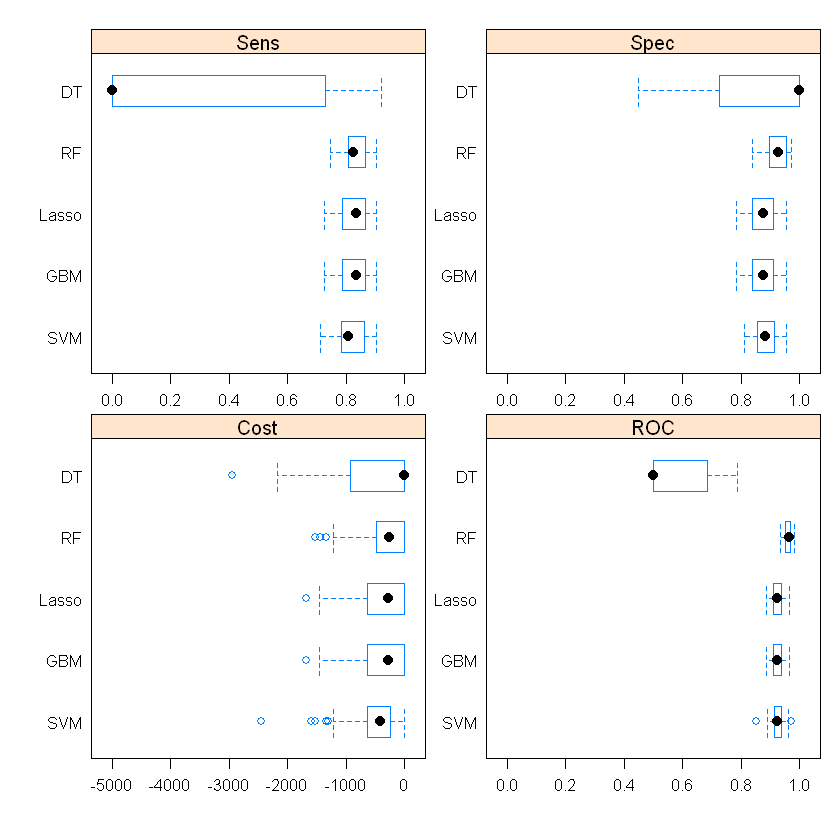

```r
bwplot(resamps,  scales = list(relation = "free"), xlim = list(c(-5000, 0), c(0, 1), c(0, 1), c(0, 1)))
```

### Step5: Test Preperation

```r
test[, c("Var_39", "Var_53")] = lapply(test[, c("Var_39", "Var_53")] , factor)
```

```r
min(test$customer_age)
```

19

```r
max(test$customer_age)
```

74

```r
test[,age_cluster:=cut(customer_age, breaks=c(18,25,30,45,74), labels=c("young", "graduate", "middle-age", "old"))]
```

### Step6: Prediction

```r
prediction = predict(rf_fit, newdata = test)
```

```r
test$pred_type = prediction
```

```r
test[,prediction:=ifelse(pred_type=="Bad", 1, 0)]
```

```r
#check table
table(test$prediction)
```

```
  0   1
745 102
```

###### The final prediction for test_ids highly different than the ones I find in final exam. This may be due to I avoided using sampled data while evaluating models, changed performance metric and used age in categoric type

```r
result = test[, c("loan_application_id", "prediction")]
```

```r
fwrite(result, "test_predictions.csv", col.names=T)
```

### Step7: Conclusion, Comments and Final Comparison

By looking at the box plots and comparing the cost metric between different approach, Random Forest still looks like the best algorithm due to its robustness in 5-repeats 10-fold cross validation. So again, it is selected as final method. For furher works one can do the followings:

- Try to perform dimensionality reduction with PCA or any other method
- Leverage scaling the data before even though most the models handle this problem
- Use broader parameter grids.
- Try other sampling methods like downsampling